# Shotgun bisulphite sequencing of the Arabidopsis genome reveals DNA methylation patterning | Nature

[Full size image](https://www.nature.com/articles/nature06745/figures/2)

Sequences with the lowest CG methylation were highly enriched for the sequence ACGT (Fig. 2 and Supplementary Fig. 9). Poorly methylated CHG sites were depleted of upstream cytosines but tended to contain cytosine after the methylated cytosine. This trend is consistent with a nearest-neighbour analysis of wheat germ DNA that found CAG and CTG sites methylated at a higher level than CCG sites<sup>10</sup>. Highly methylated CHH sequences had a very specific configuration, with a tendency for cytosines and CG dinucleotides to be present upstream (Supplementary Table 3) and the sequence TA following the methylated cytosine. In contrast, poorly methylated CHH sequences always contained a cytosine after the methylated cytosine, and frequently contained a cytosine but always lacked an adenine two nucleotides downstream (Fig. 2 and Supplementary Fig. 8). These results are consistent with data from individual plant genes showing that cytosines preceding a cytosine are undermethylated whereas those following a cytosine are more heavily methylated<sup>11,12,13</sup>, and with asymmetric methylation in mammalian genomes that is found at CT and CA sequences more frequently than CC sequences<sup>14</sup>. It is also of interest that *Arabidopsis* telomere sequences (CCCTAAA)<sub>*n*</sub> are composed of nearly optimal asymmetric target units, possibly explaining the high methylation of the third cytosines (Fig. 1e). Although the molecular basis for these trends is unknown, the results suggest that DNA methyltransferases show strong sequence preferences beyond the CG, CHG and CHH contexts. Finally, we found that regions with higher concentrations of CG dinucleotides were more heavily methylated at CG sites (Supplementary Fig. 10). Interestingly, this is different from observations in mammalian genomes, which show the opposite trend: CGs are depleted in methylated regions and at a higher density in unmethylated CpG islands.

We used autocorrelation analysis to examine the correlation between methylation in different sequence contexts and methylation at adjacent residues. We observed significant correlation between methylated cytosines for distances up to 5,000 nucleotides or more—probably a reflection of regional foci of methylation throughout the genome and of large blocks of pericentromeric heterochromatin (Supplementary Fig. 11 and Supplementary Table 5). We also found a high correlation of CHG and CHH methylation within several nucleotides downstream of methylated CG sites, and a tendency for CHH methylation four nucleotides downstream of methylation at CHG sites (Supplementary Fig. 12 and Supplementary Table 5). These data suggest complex interactions between the different types of methylation.

We analysed the propensity for full methylation of the strand-symmetrical CG and partially symmetrical CHG sequences. As expected, CG methylation on one strand was highly correlated with CG methylation on the opposing strand. We also saw a high correlation for CHG methylation of the two strands, showing that, as for CG methylation, CHG sites show a strong tendency for symmetrical methylation (Supplementary Fig. 12). Unexpectedly, we observed a correlation between CHH methylation on one strand, and methylation at the cytosine three nucleotides downstream and on the opposite strand (Supplementary Fig. 12 and Supplementary Table 5). Because the sequence of such sites is CHHG, this shows that ‘asymmetric’ methylation shows a propensity for symmetrical methylation at these sites, even though methylation on CHHG sites is not particularly prominent in the genome (Supplementary Fig. 8 and Supplementary Table 4).

Autocorrelation analysis also revealed a marked periodicity of ten nucleotides (the length of one helical DNA turn) for CHH methylation (Fig. 3a, b). We confirmed this period using data from the whole genome and from regions previously defined to be methylated, and confirmed that the periodicity was not caused by our computational filtering of the data (Supplementary Fig. 13). We observed this period both when looking at the average methylation of cytosines in the genome (Fig. 3a, b and Supplementary Fig. 13) and when individual reads are examined directly (Supplementary Fig. 14). Mammalian DNA methyltransferase 3a (Dnmt3a) was recently shown to act as a tetramer with DNA methyltransferase 3-like protein (Dnmt3L), and two active sites methylate two CG sequences spaced ∼8–10 nucleotides apart<sup>15</sup>. Because DOMAINS REARRANGED METHYLASE 2 (DRM2) is the main enzyme controlling asymmetric methylation in *Arabidopsis* and is a homologue of Dnmt3<sup>16</sup>, these data suggest that the mechanism of action of these enzymes may be conserved between plants and mammals.

**Figure 3: **Methylation shows periodic patterns.****

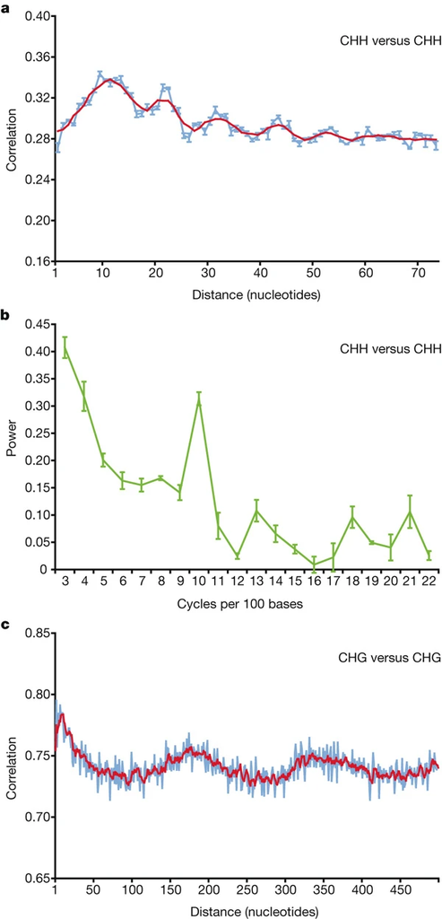

**a**, **c**, Correlation of the methylation status of cytosines in a CHH (**a**) and CHG (**c**) context. The *x* axis indicates the distance between the two cytosines. The *y* axis indicates the level of autocorrelation in methylation. The red line shows a running average of windows that are ±2 bases around a single base. **b**, Fourier transform analysis of CHH methylation correlation. The *x* axis indicates the number of cycles per 100 bases. The *y* axis is the amplitude of the corresponding frequency. The peak at position 10 represents a periodicity of ten nucleotides, with a *P*-value smaller than 10<sup>-108</sup> for observing this periodicity value by chance in random permutations of the genome. In **a**–**c**, Monte Carlo sampling of three data sets, each consisting of half the data, was used to compute the mean and standard deviations of the autocorrelations and Fourier transforms. Mean values are shown, and error bars (**a** and **b**) represent standard deviations. In **a** and **b**, methylation from the whole genome was analysed, whereas, in **c**, the analysis was restricted to previously defined methylated sequences<sup>3</sup> (see Supplementary Fig. 15 for details).

[Full size image](https://www.nature.com/articles/nature06745/figures/3)

Autocorrelation also showed a period of 167 nucleotides (Fig. 3c and Supplementary Fig. 15), which is similar to, but slightly shorter than, estimates of the average spacing of nucleosomes in plant chromatin<sup>17,18,19</sup>. One explanation for this period is that nucleosomes or particular histone modifications might dictate access to the DNA by methyltransferase proteins. Furthermore, the slightly shorter length of 167 nucleotides relative to most estimates of plant nucleosome repeat length (175–185 nucleotides)<sup>17,18,19</sup> suggests that DNA-methylated chromatin may be more compact because of shorter linker regions or depletion in linker histones<sup>20</sup>.

We used BS-Seq to study the genome-wide effects of a variety of *Arabidopsis* methyltransferase mutants on DNA methylation (Fig. 4). The MET1, CMT3 and DRM1/DRM2 DNA methyltransferase enzymes are mostly responsible for CG, CHG and CHH methylation, respectively, although at many loci CHG and CHH methylation is redundantly controlled by CMT3 and DRM1/DRM2 (refs 1 and 12). We sequenced and mapped ∼90 million nucleotides of BS-Seq data from each of several combinations of DNA methyltransferase mutants (Supplementary Table 1) including *met1* single mutants, *cmt3* single mutants, *drm1 drm2* double mutants, *met1 cmt3* double mutants, *met1 drm1 drm2* triple mutants and *drm1 drm2 cmt3* triple mutants<sup>21</sup>. We then analysed the effect of these mutants on global methylation, on methylation in genes and chromosomes, and on methylation in rDNA and telomeres (Supplementary Table 6, Figs 1e and 4, and Supplementary Figs 7 and 16). The *met1* single mutant, or any mutant combination containing *met1*, essentially eliminated CG methylation throughout the genome. For instance, gene-body methylation, which is almost exclusively CG, was eliminated in all *met1*-containing strains (Fig. 4a). Surprisingly, in the *met1 drm1 drm2* triple mutant, we observed a marked hypermethylation of CHG sites in the bodies of genes (Fig. 4a). This methylation was skewed towards the 3′ end and in this way assumed a pattern of methylation similar to the missing CG methylation. Although previous studies have suggested that the *drm1 drm2 cmt3* triple mutant eliminates CHG and CHH methylation<sup>12</sup>, BS-Seq data shows residual methylation (Supplementary Table 6), particularly in pericentromeric heterochromatin (Fig. 4b), suggesting that another enzyme is involved<sup>22</sup>. Furthermore, the *met1 cmt3* double mutant was equally effective in reducing CHH methylation, as was *drm1 drm2 cmt3* (Supplementary Table 6), suggesting that CHH methylation depends in part on the presence of CG and CHG methylation. These compensating behaviours suggest that the different DNA methyltransferases act redundantly, and help to explain the viability of these mutant combinations, whereas the *met1 cmt3 drm1 drm2* quadruple mutant causes embryonic lethality<sup>21</sup>.

**Figure 4: **BS-Seq profiling of methylation mutants in** *Arabidopsis* **and mouse.****

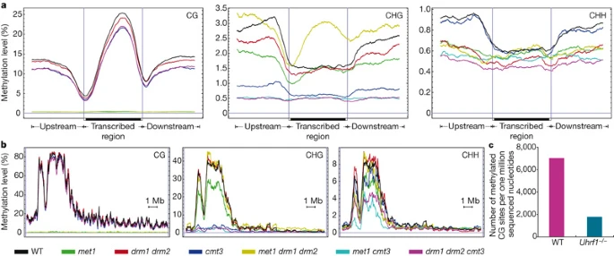

[Full size image](https://www.nature.com/articles/nature06745/figures/4)

The BS-Seq procedure described here should be generally useful in other organisms. For example, we applied BS-Seq to quantify the overall genomic methylation difference between wild-type mouse embryonic stem cells and cells carrying a mutation in the *Uhrf1* gene recently shown to control maintenance of CG methylation<sup>23,24</sup>. By analysing ∼60 million nucleotides of shotgun sequencing data from each, we found that *Uhrf1*<sup>*–/–*</sup> cells contained only 25% of the CpG methylation level of the wild type (Fig. 4c). Furthermore, to demonstrate that the complete analysis pipeline used for *Arabidopsis* is applicable to larger genomes, we produced a library from mouse germ-cell tissue and generated ∼46 million nucleotides of high quality mapped BS-Seq data. Approximately 66% of the reads mapped uniquely—a level only slightly lower than that of *Arabidopsis* (Supplementary Table 1), suggesting that it is practical to apply BS-Seq to entire mammalian genomes.

In summary, BS-Seq analysis of wild type and methyltransferase mutants has allowed a more detailed characterization of the *Arabidopsis* methylome. In addition, the computational approaches developed in this study should be generally useful for other short-read sequencing genomics approaches. An installation of the UCSC browser allowing community access to detailed methylation patterns of individual genes and a source code distribution of the computational methods are available at http://epigenomics.mcdb.ucla.edu/BS-Seq/.

## Methods Summary

### Construction and sequencing of DNA libraries

Bisulphite treatment of DNA was performed as described previously<sup>25</sup>, except that adaptor sequences and PCR conditions were modified and optimized for this study. Library generation and ultra-high-throughput sequencing were carried out according to manufacturer instructions (Illumina).

### Processing of sequence data and mapping of reads

Raw data from Illumina GA were processed using the initial stages of the Solexa software pipeline (Illumina) into short reads, except that per-lane per-cycle multidimensional gaussian mixture models (GMMs) were developed to optimize base call A-versus-C-versus-G-versus-T probability distribution accuracies at each sequenced base compared to the Solexa software pipeline’s ‘_prb’ files. Sequenced reads were mapped to reference genomes fully using per-base probabilities from the GMMs using highly optimized novel C++ tools. Sequences that mapped to more than one position with similar scores (within 1% of the maximum likelihood mapping) were removed to retain only reads that mapped uniquely. To eliminate unconverted bisulphite reads, a filter discarded reads with three or more consecutive methylated cytosines when each of these was in a CHH context, resulting in a loss of ∼0.23% of reads. This filter was effective and gave only minimal loss of true CHH methylation (Supplementary Table 1 and Supplementary Figs 13, 17 and 18).

### Validation of BS-Seq results

Traditional bisulphite sequencing was used to validate BS-Seq results at select loci (Supplementary Table 2 and Supplementary Figs 4, 6 and 17). The PCR primers used in the validation are listed in Supplementary Table 7.

## References

1. Henderson, I. R. & Jacobsen, S. E. Epigenetic inheritance in plants. *Nature* **447**, 418–424 (2007)

   [Article](https://doi.org/10.1038%2Fnature05917) [ADS](http://adsabs.harvard.edu/cgi-bin/nph-data_query?link_type=ABSTRACT&bibcode=2007Natur.447..418H) [CAS](https://www.nature.com/articles/cas-redirect/1:CAS:528:DC%2BD2sXlsFOgs78%3D) Google Scholar
2. Goll, M. G. & Bestor, T. H. Eukaryotic cytosine methyltransferases. *Annu. Rev. Biochem.* **74**, 481–514 (2005)

   [Article](https://doi.org/10.1146%2Fannurev.biochem.74.010904.153721) [CAS](https://www.nature.com/articles/cas-redirect/1:CAS:528:DC%2BD2MXpsVensLw%3D) Google Scholar
3. Zhang, X. et al. Genome-wide high-resolution mapping and functional analysis of DNA methylation in *Arabidopsis*. *Cell* **126**, 1189–1201 (2006)

   [Article](https://doi.org/10.1016%2Fj.cell.2006.08.003) [CAS](https://www.nature.com/articles/cas-redirect/1:CAS:528:DC%2BD28XhtVCnsrvP) Google Scholar
4. Zilberman, D., Gehring, M., Tran, R. K., Ballinger, T. & Henikoff, S. Genome-wide analysis of *Arabidopsis thaliana* DNA methylation uncovers an interdependence between methylation and transcription. *Nature Genet.* **39**, 61–69 (2007)

   [Article](https://doi.org/10.1038%2Fng1929) [CAS](https://www.nature.com/articles/cas-redirect/1:CAS:528:DC%2BD28XhtlGktLvJ) Google Scholar
5. Vaughn, M. W. et al. Epigenetic natural variation in *Arabidopsis* *thaliana*. *PLoS Biol.* **5**, e174 (2007)

   [Article](https://doi.org/10.1371%2Fjournal.pbio.0050174) Google Scholar
6. Bentley, D. R. Whole-genome re-sequencing. *Curr. Opin. Genet. Dev.* **16**, 545–552 (2006)

   [Article](https://doi.org/10.1016%2Fj.gde.2006.10.009) [CAS](https://www.nature.com/articles/cas-redirect/1:CAS:528:DC%2BD28Xht1Cmt7jN) Google Scholar
7. Frommer, M. et al. A genomic sequencing protocol that yields a positive display of 5-methylcytosine residues in individual DNA strands. *Proc. Natl Acad. Sci. USA* **89**, 1827–1831 (1992)

   [Article](https://doi.org/10.1073%2Fpnas.89.5.1827) [ADS](http://adsabs.harvard.edu/cgi-bin/nph-data_query?link_type=ABSTRACT&bibcode=1992PNAS...89.1827F) [CAS](https://www.nature.com/articles/cas-redirect/1:CAS:528:DyaK38XhvVyktL0%3D) Google Scholar
8. Ngernprasirtsiri, J., Kobayashi, H. & Akazawa, T. DNA methylation as a mechanism of transcriptional regulation in nonphotosynthetic plastids in plant cells. *Proc. Natl Acad. Sci. USA* **85**, 4750–4754 (1988)

   [Article](https://doi.org/10.1073%2Fpnas.85.13.4750) [ADS](http://adsabs.harvard.edu/cgi-bin/nph-data_query?link_type=ABSTRACT&bibcode=1988PNAS...85.4750N) [CAS](https://www.nature.com/articles/cas-redirect/1:CAS:528:DyaL1cXltVGktrs%3D) Google Scholar
9. Tran, R. K. et al. DNA methylation profiling identifies CG methylation clusters in *Arabidopsis* genes. *Curr. Biol.* **15**, 154–159 (2005)

   [Article](https://doi.org/10.1016%2Fj.cub.2005.01.008) [CAS](https://www.nature.com/articles/cas-redirect/1:CAS:528:DC%2BD2MXmvFeltg%3D%3D) Google Scholar
10. Gruenbaum, Y., Naveh-Many, T., Cedar, H. & Razin, A. Sequence specificity of methylation in higher plant DNA. *Nature* **292**, 860–862 (1981)

    [Article](https://doi.org/10.1038%2F292860a0) [ADS](http://adsabs.harvard.edu/cgi-bin/nph-data_query?link_type=ABSTRACT&bibcode=1981Natur.292..860G) [CAS](https://www.nature.com/articles/cas-redirect/1:CAS:528:DyaL38Xjs1ag) Google Scholar
11. Meyer, P., Niedenhof, I. & ten Lohuis, M. Evidence for cytosine methylation of non-symmetrical sequences in transgenic *Petunia hybrida*. *EMBO J.* **13**, 2084–2088 (1994)

    [Article](https://doi.org/10.1002%2Fj.1460-2075.1994.tb06483.x) [CAS](https://www.nature.com/articles/cas-redirect/1:CAS:528:DyaK2cXksFWgtLY%3D) Google Scholar
12. Cao, X. & Jacobsen, S. E. Locus-specific control of asymmetric and CpNpG methylation by the DRM and CMT3 methyltransferase genes. *Proc. Natl Acad. Sci. USA* **99** (Suppl 4). 16491–16498 (2002)

    [Article](https://doi.org/10.1073%2Fpnas.162371599) [ADS](http://adsabs.harvard.edu/cgi-bin/nph-data_query?link_type=ABSTRACT&bibcode=2002PNAS...9916491C) [CAS](https://www.nature.com/articles/cas-redirect/1:CAS:528:DC%2BD38Xps12ht7c%3D) Google Scholar
13. Dieguez, M. J., Vaucheret, H., Paszkowski, J. & Mittelsten Scheid, O. Cytosine methylation at CG and CNG sites is not a prerequisite for the initiation of transcriptional gene silencing in plants, but it is required for its maintenance. *Mol. Gen. Genet.* **259**, 207–215 (1998)

    [Article](https://link.springer.com/doi/10.1007/s004380050806) [CAS](https://www.nature.com/articles/cas-redirect/1:CAS:528:DyaK1cXns1GnsL0%3D) Google Scholar
14. Ramsahoye, B. H. et al. Non-CpG methylation is prevalent in embryonic stem cells and may be mediated by DNA methyltransferase 3a. *Proc. Natl Acad. Sci. USA* **97**, 5237–5242 (2000)

    [Article](https://doi.org/10.1073%2Fpnas.97.10.5237) [ADS](http://adsabs.harvard.edu/cgi-bin/nph-data_query?link_type=ABSTRACT&bibcode=2000PNAS...97.5237R) [CAS](https://www.nature.com/articles/cas-redirect/1:CAS:528:DC%2BD3cXjsVWntLs%3D) Google Scholar
15. Jia, D., Jurkowska, R. Z., Zhang, X., Jeltsch, A. & Cheng, X. Structure of Dnmt3a bound to Dnmt3L suggests a model for *de novo* DNA methylation. *Nature* **449**, 248–251 (2007)

    [Article](https://doi.org/10.1038%2Fnature06146) [ADS](http://adsabs.harvard.edu/cgi-bin/nph-data_query?link_type=ABSTRACT&bibcode=2007Natur.449..248J) [CAS](https://www.nature.com/articles/cas-redirect/1:CAS:528:DC%2BD2sXhtVagtbrF) Google Scholar
16. Cao, X. et al. Conserved plant genes with similarity to mammalian de novo DNA methyltransferases. *Proc. Natl Acad. Sci. USA* **97**, 4979–4984 (2000)

    [Article](https://doi.org/10.1073%2Fpnas.97.9.4979) [ADS](http://adsabs.harvard.edu/cgi-bin/nph-data_query?link_type=ABSTRACT&bibcode=2000PNAS...97.4979C) [CAS](https://www.nature.com/articles/cas-redirect/1:CAS:528:DC%2BD3cXivFKis78%3D) Google Scholar
17. Bers, E. P., Singh, N. P., Pardonen, V. A., Lutova, L. A. & Zalensky, A. O. Nucleosomal structure and histone H1 subfractional composition of pea (Pisum sativum) root nodules, radicles and callus chromatin. *Plant Mol. Biol.* **20**, 1089–1096 (1992)

    [Article](https://link.springer.com/doi/10.1007/BF00028895) [CAS](https://www.nature.com/articles/cas-redirect/1:CAS:528:DyaK3sXls1ahsw%3D%3D) Google Scholar
18. Vershinin, A. V. & Heslop-Harrison, J. S. Comparative analysis of the nucleosomal structure of rye, wheat and their relatives. *Plant Mol. Biol.* **36**, 149–161 (1998)

    [Article](https://doi.org/10.1023%2FA%3A1005912822671) [CAS](https://www.nature.com/articles/cas-redirect/1:CAS:528:DyaK1cXht1akt7k%3D) Google Scholar
19. Fulnecek, J., Matyasek, R., Kovarik, A. & Bezdek, M. Mapping of 5-methylcytosine residues in *Nicotiana tabacum* 5S rRNA genes by genomic sequencing. *Mol. Gen. Genet.* **259**, 133–141 (1998)

    [Article](https://link.springer.com/doi/10.1007/s004380050798) [CAS](https://www.nature.com/articles/cas-redirect/1:CAS:528:DyaK1cXns1Ggtro%3D) Google Scholar
20. Fan, Y. et al. Histone H1 depletion in mammals alters global chromatin structure but causes specific changes in gene regulation. *Cell* **123**, 1199–1212 (2005)

    [Article](https://doi.org/10.1016%2Fj.cell.2005.10.028) [CAS](https://www.nature.com/articles/cas-redirect/1:CAS:528:DC%2BD28XktlWisw%3D%3D) Google Scholar
21. Zhang, X. & Jacobsen, S. E. Genetic analyses of DNA methyltransferases in *Arabidopsis thaliana*. *Cold Spring Harb. Symp. Quant. Biol.* **71**, 439–447 (2006)

    [Article](https://doi.org/10.1101%2Fsqb.2006.71.047) [CAS](https://www.nature.com/articles/cas-redirect/1:CAS:528:DC%2BD2sXls1yrtLk%3D) Google Scholar
22. Henderson, I. R. et al. Dissecting *Arabidopsis* *thaliana* DICER function in small RNA processing, gene silencing and DNA methylation patterning. *Nature Genet.* **38**, 721–725 (2006)

    [Article](https://doi.org/10.1038%2Fng1804) [CAS](https://www.nature.com/articles/cas-redirect/1:CAS:528:DC%2BD28XltVOhur0%3D) Google Scholar
23. Bostick, M. et al. UHRF1 plays a role in maintaining DNA methylation in mammalian cells. *Science* **317**, 1760–1764 (2007)

    [Article](https://doi.org/10.1126%2Fscience.1147939) [ADS](http://adsabs.harvard.edu/cgi-bin/nph-data_query?link_type=ABSTRACT&bibcode=2007Sci...317.1760B) [CAS](https://www.nature.com/articles/cas-redirect/1:CAS:528:DC%2BD2sXhtVGmsLbN) Google Scholar
24. Sharif, J. et al. The SRA protein Np95 mediates epigenetic inheritance by recruiting Dnmt1 to methylated DNA. *Nature* **450**, 908–912 (2007)

    [Article](https://doi.org/10.1038%2Fnature06397) [ADS](http://adsabs.harvard.edu/cgi-bin/nph-data_query?link_type=ABSTRACT&bibcode=2007Natur.450..908S) [CAS](https://www.nature.com/articles/cas-redirect/1:CAS:528:DC%2BD2sXhtl2gsb3L) Google Scholar
25. Meissner, A. et al. Reduced representation bisulfite sequencing for comparative high-resolution DNA methylation analysis. *Nucleic Acids Res.* **33**, 5868–5877 (2005)

    [Article](https://doi.org/10.1093%2Fnar%2Fgki901) [CAS](https://www.nature.com/articles/cas-redirect/1:CAS:528:DC%2BD2MXht1OmtrvM) Google Scholar
26. Rajagopalan, R., Vaucheret, H., Trejo, J. & Bartel, D. P. A diverse and evolutionarily fluid set of microRNAs in *Arabidopsis* thaliana. *Genes Dev.* **20**, 3407–3425 (2006)

    [Article](https://doi.org/10.1101%2Fgad.1476406) [CAS](https://www.nature.com/articles/cas-redirect/1:CAS:528:DC%2BD2sXhs1ejsw%3D%3D) Google Scholar

[Download references](https://citation-needed.springer.com/v2/references/10.1038/nature06745?format=refman&flavour=references)

## Acknowledgements

We thank Y. Bernatavichute for nuclear DNA isolation protocols, A. Clarke for providing embryonic stem cell DNA, A. Girard and G. Hannon for providing mouse germ cell DNA, J. Hetzel for technical assistance, and C. F. Li for assistance with rDNA annotation. S.F. is a Howard Hughes Medical Institute Fellow of the Life Science Research Foundation. X.Z. was supported by a fellowship from the Jonsson Cancer Center Foundation. S.E.J. is an investigator of the Howard Hughes Medical Institute. This work was supported in part by grants from the NSF Plant Genome Research Program and the NIH, and some aspects of the work were performed in the UCLA DNA Microarray Facility.

**Author Contributions** S.J.C. developed computational methods for mapping and base-calling. S.F. designed and created DNA libraries and performed all molecular biology experiments. S.F., Z.C., B.M. and S.F.N. sequenced the libraries. M.P., S.J.C., S.F. and S.E.J. analysed data. S.E.J. and M.P. designed and directed the study. X.Z., C.D.H. and S.P. assisted in the design of experiments. S.F. and S.J.C. wrote the manuscript.

## Author information

Author notes

1. Xiaoyu Zhang

   Present address: Present address: Department of Plant Biology, University of Georgia, Athens, Georgia 30602, USA.,
2. Shawn J. Cokus and Suhua Feng: These authors contributed equally to this work.

### Authors and Affiliations

1. Department of Molecular, Cell, and Developmental Biology,

   Shawn J. Cokus, Suhua Feng, Xiaoyu Zhang, Matteo Pellegrini & Steven E. Jacobsen
2. Howard Hughes Medical Institute,,

   Suhua Feng & Steven E. Jacobsen
3. Department of Human Genetics, David Geffen School of Medicine, University of California at Los Angeles, Los Angeles, California 90095, USA,

   Zugen Chen, Barry Merriman & Stanley F. Nelson
4. Illumina Inc., Hayward, California 94545, USA,

   Christian D. Haudenschild
5. New England BioLabs, Ipswich, Massachusetts 01938, USA,

   Sriharsa Pradhan

### Corresponding authors

Correspondence to Matteo Pellegrini or Steven E. Jacobsen.

## Ethics declarations

### Competing interests

C. Haudenschild is an employee of Illumina Inc., the manufacturer of the high throughput sequencing system used in this work.

## Supplementary information

This file contains Supplementary Figures 1-18 with Legends and Supplementary Methods. (PDF 5784 kb)

This file contains Supplementary Table 1. (XLS 17 kb)

This file contains Supplementary Table 2. (XLS 18 kb)

This file contains Supplementary Table 3. (XLS 978 kb)

This file contains Supplementary Table 4. (XLS 807 kb)

This file contains Supplementary Table 5. (XLS 3593 kb)

This file contains Supplementary Table 6. (XLS 9 kb)

This file contains Supplementary Table 7. (XLS 14 kb)

## Rights and permissions

Reprints and permissions

## About this article

### Cite this article

Cokus, S., Feng, S., Zhang, X. *et al.* Shotgun bisulphite sequencing of the *Arabidopsis* genome reveals DNA methylation patterning. *Nature* **452**, 215–219 (2008). https://doi.org/10.1038/nature06745

[Download citation](https://citation-needed.springer.com/v2/references/10.1038/nature06745?format=refman&flavour=citation)

- Received: 28 November 2007
- Accepted: 30 January 2008
- Published: 17 February 2008
- Issue Date: 13 March 2008
- DOI: https://doi.org/10.1038/nature06745

### Share this article

Anyone you share the following link with will be able to read this content:

Provided by the Springer Nature SharedIt content-sharing initiative

## This article is cited by

- - Xiaomin Yang
  - Zhigang Bai
  - Wuwei Ye

  *BMC Plant Biology* (2024)

- - Guilherme de Sena Brandine
  - Kenneth I. Aston
  - Andrew D. Smith

  *Clinical Epigenetics* (2023)

- - Zac Chatterton
  - Praves Lamichhane
  - John B. Kwok

  *Cell & Bioscience* (2023)

- - Ping Guo
  - Hailing Zheng
  - Hongliang Chen

  *Clinical Epigenetics* (2023)

- - Pei-Yu Lin
  - Ya-Ting Chang
  - Pao-Yang Chen

  *Epigenetics & Chromatin* (2023)

[Download PDF](https://www.nature.com/articles/nature06745.pdf)

## Editorial Summary

### Mapping the methylome

A newly developed method of characterizing an organism's 'methylome', that is the pattern of DNA methylation in the genome, has been used to generate a map of methylated cytosines in *Arabidopsis* to single base-pair resolution. The procedure, termed BS-Seq, combines bisulphite treatment of genomic DNA with ultra-high-throughput DNA sequencing to achieve a more precise and comprehensive result than previously possible. DNA methylation is an important factor in regulating gene expression, and this method, which can be applied to larger genomes like the mouse as well as to *Arabidopsis*, could prove a significant advance in the study of this form of gene regulation.

[figure not shown]